# Modeling and prediction for movies

## Setup

### Load packages

```r
library(ggplot2)
library(gridExtra)
library(GGally)
library(dplyr)
library(statsr)
library(xtable)
```

### Load data

Make sure your data and R Markdown files are in the same directory. When loaded your data file will be called `movies`. Delete this note when before you submit your work.

```r
load("movies.Rdata")
nrow(movies)
```

```
## [1] 651
```

## Part 1: Data

According to the codebook, the data is a random sample of movies produced before 2016. Given there are 600 movies made every year in US, this can be considered a good sample if all the movies have been considered when sampling was performed. Since that information is missing I would not generalize the results determined after the analysis and modeling.

Since this data is just random observations from a population and is not gathered under experimental setup, one cannot attribute the results to causation. But there may exist correlations among the predictors.

```r
  movies <- movies %>% filter(!is.na(audience_score))
  nrow(movies)
```

```
## [1] 651
```

## Part 2: Research question

We are going to create a multiple linear regression model that can estimate audience score given all the relevant predictors. What predictors will be choosen will depend on the exploratory data analysis performed on the variables.

## Part 3: Exploratory data analysis

The predictors to choose for modeling

```r
  names(movies)
```

```
##  [1] "title"            "title_type"       "genre"
##  [4] "runtime"          "mpaa_rating"      "studio"
##  [7] "thtr_rel_year"    "thtr_rel_month"   "thtr_rel_day"
## [10] "dvd_rel_year"     "dvd_rel_month"    "dvd_rel_day"
## [13] "imdb_rating"      "imdb_num_votes"   "critics_rating"
## [16] "critics_score"    "audience_rating"  "audience_score"
## [19] "best_pic_nom"     "best_pic_win"     "best_actor_win"
## [22] "best_actress_win" "best_dir_win"     "top200_box"
## [25] "director"         "actor1"           "actor2"
## [28] "actor3"           "actor4"           "actor5"
## [31] "imdb_url"         "rt_url"
```

The features `imdb_url` and rotten tomatoes url `rt_url` are just hyper links and can be omitted from modelling. Lets check whether there are collinear predictors and try to eliminate them or combine them as seem fit.

Lets see how the year, month and days affects the `audience_score`

The theatrical/dvd release month doesnt seem to be variable across months, but there are more variable in a month.

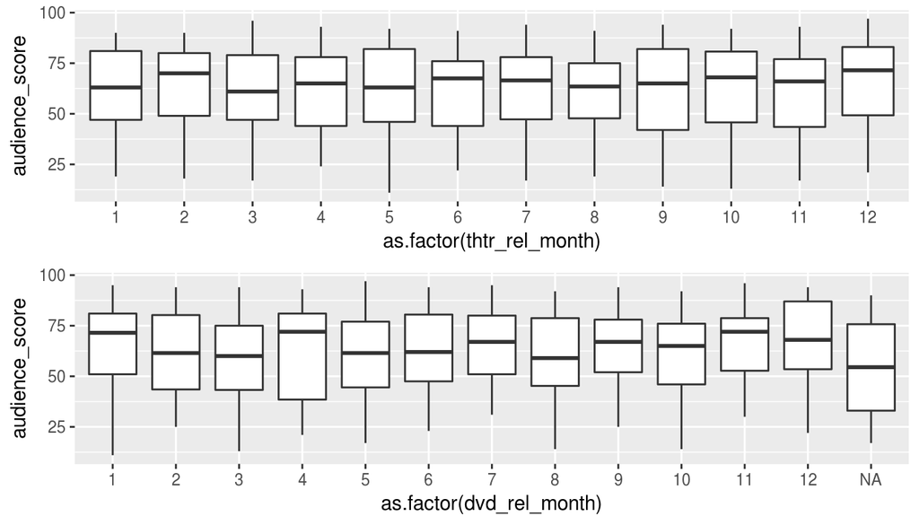

```r
par(mfrow=c(2,2))
bp1<- ggplot(data=movies, aes(x=as.factor(thtr_rel_month) ,y=audience_score))+geom_boxplot()
bp2<- ggplot(data=movies, aes(x=as.factor(dvd_rel_month) ,y=audience_score))+geom_boxplot()

grid.arrange(bp1,bp2)
```

The theatrical/dvd release day does seem to have more variability.

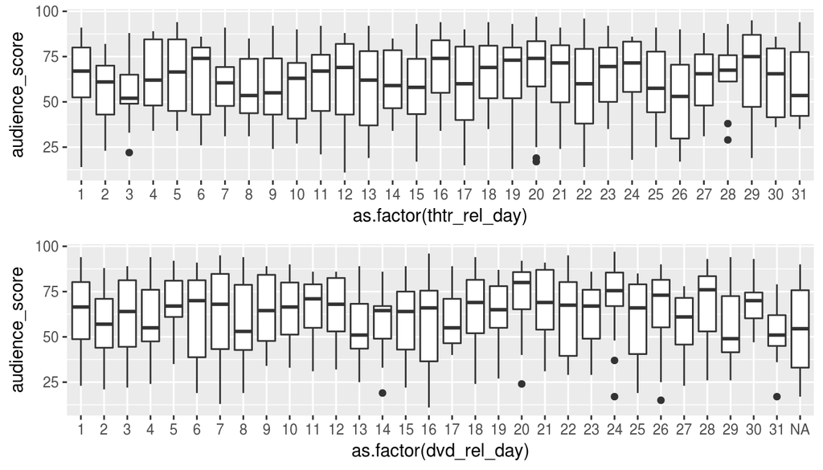

```r
par(mfrow=c(2,2))
bp1<- ggplot(data=movies, aes(x=as.factor(thtr_rel_day) ,y=audience_score))+geom_boxplot()
bp2<- ggplot(data=movies, aes(x=as.factor(dvd_rel_day) ,y=audience_score))+geom_boxplot()

grid.arrange(bp1,bp2)
```

The theatrical/dvd release year also has more variability

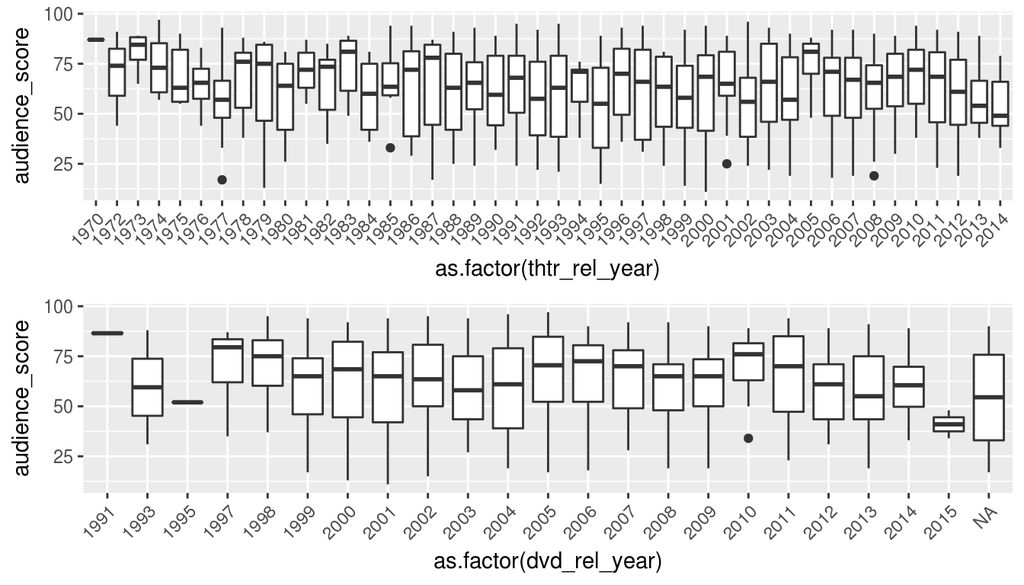

```r
par(mfrow=c(2,2))
bp1<- ggplot(data=movies, aes(y=audience_score, x=as.factor(thtr_rel_year))) +
      geom_boxplot() +
      theme(axis.text.x = element_text(angle = 45, hjust = 1))
bp2<- ggplot(data=movies, aes(y=audience_score, x=as.factor(dvd_rel_year))) +
      geom_boxplot() +
      theme(axis.text.x = element_text(angle = 45, hjust = 1))
grid.arrange(bp1,bp2)
```

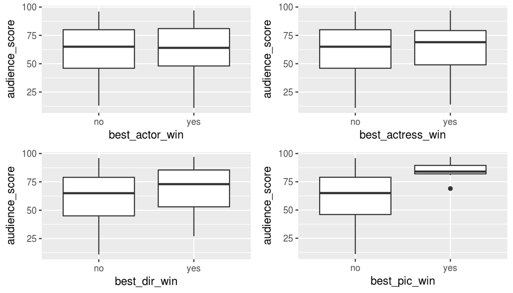

```r
par(mfrow=c(2,2))
bp1<- ggplot(data=movies, aes(x=best_actor_win ,y=audience_score))+geom_boxplot()
bp2<- ggplot(data=movies, aes(x=best_actress_win ,y=audience_score))+geom_boxplot()
bp3<- ggplot(data=movies, aes(x=best_dir_win ,y=audience_score))+geom_boxplot()
bp4<- ggplot(data=movies, aes(x=best_pic_win ,y=audience_score))+geom_boxplot()

grid.arrange(bp1,bp2,bp3,bp4)
```

Feature `best_pic_nom` and `top200_box` are good predictors too.

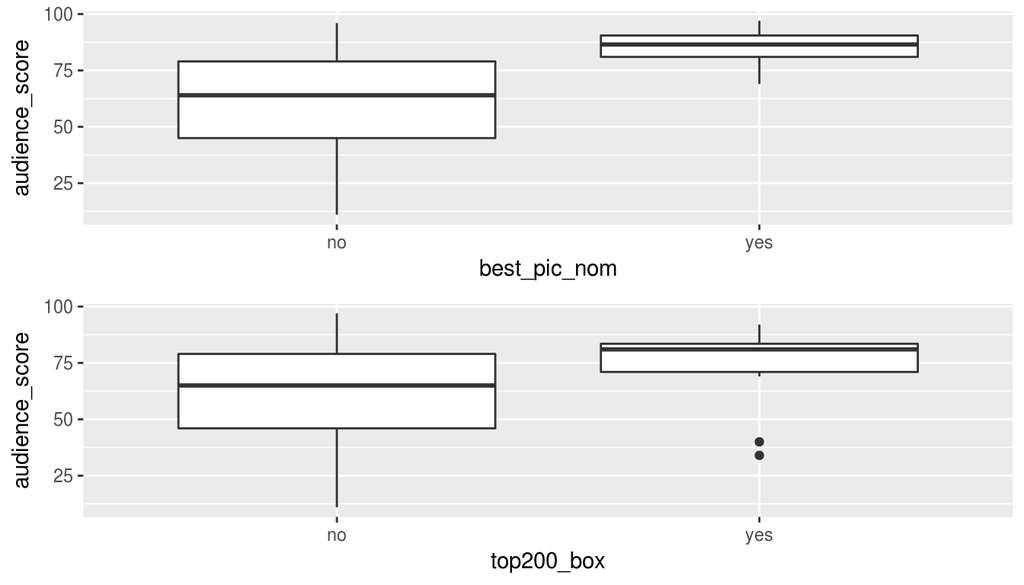

```r
par(mfrow=c(2,1))
bp1<- ggplot(data=movies, aes(x=best_pic_nom ,y=audience_score))+geom_boxplot()
bp2<- ggplot(data=movies, aes(x=top200_box ,y=audience_score))+geom_boxplot()

grid.arrange(bp1,bp2)
```

Lets explore how runtime affects the audience score alont with ratings. We can clearly see how `critics_rating`, `audience_rating` and `imdb_rating` are able to capture difference range in the audience score.

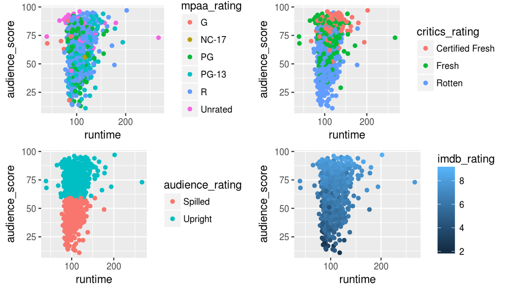

```r
par(mfrow=c(2,2))

bp1<- ggplot(data=movies, aes(x=runtime ,y=audience_score, color = mpaa_rating)) +
      geom_point()
bp2<- ggplot(data=movies, aes(x=runtime ,y=audience_score, color = critics_rating)) +
      geom_point()
bp3<- ggplot(data=movies, aes(x=runtime ,y=audience_score, color = audience_rating)) +
      geom_point()
bp4<- ggplot(data=movies, aes(x=runtime ,y=audience_score, color = imdb_rating)) +
      geom_point()

grid.arrange(bp1,bp2,bp3,bp4)
```

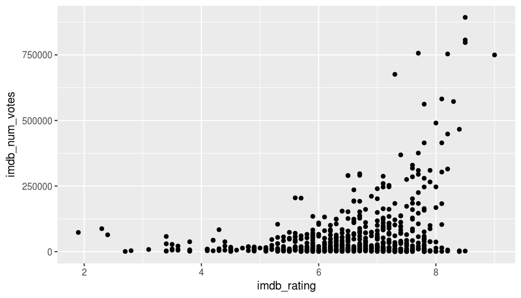

```r
  ggplot(data=movies, aes(x=imdb_rating, y=imdb_num_votes)) +
  geom_point()
```

Two predictors `imdb_rating` and `imdb_num_votes` are correlated and hence lets form a variables `imdb_score` that can be more representative of these 2 features combined. we take log of the number of votes and add them to the score.

```r
  movies$imdb_score <- movies$imdb_rating + log(movies$imdb_num_votes)
```

`imdb_score` can be a good predictor too sicne we can definitely see correlation.

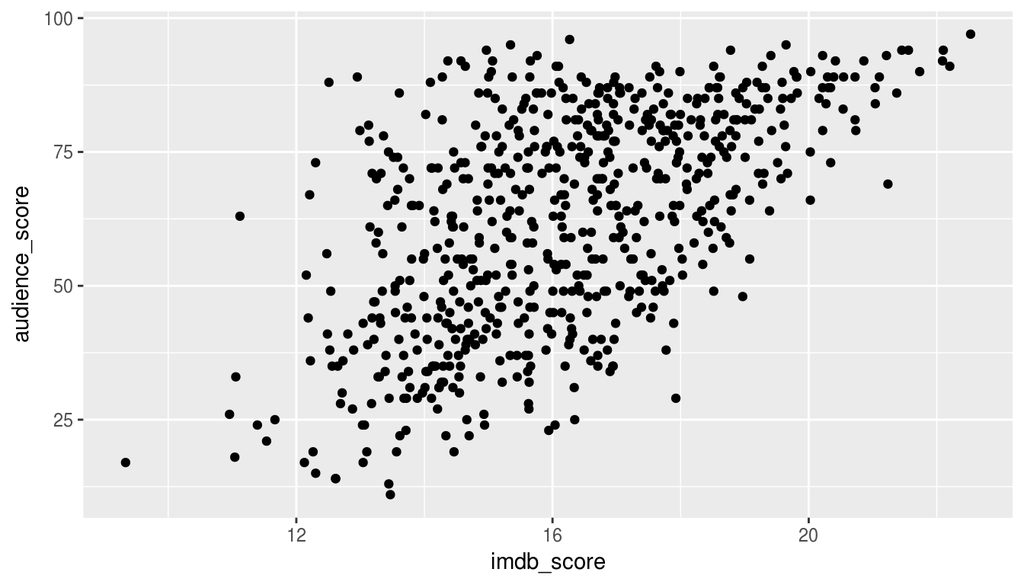

```r
  ggplot(data=movies, aes(x=imdb_score, y=audience_score)) +
  geom_point()
```

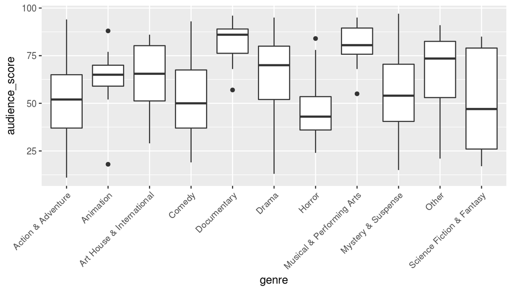

```r
  ggplot(data=movies, aes(x=genre, y=audience_score)) +
  geom_boxplot() +
  theme(axis.text.x = element_text(angle = 45, hjust = 1))
```

Since `audience_rating` and `audience_score` are very similar or even inter changeable, lets omit audience_rating from modeling.

## Part 4: Modeling

Lets build the model using the following predictors that has been explored in the previous section. We are also considering the new `imdb_score` predictor created.

The variables selected seems to exhibit collinearity that is tolerable.

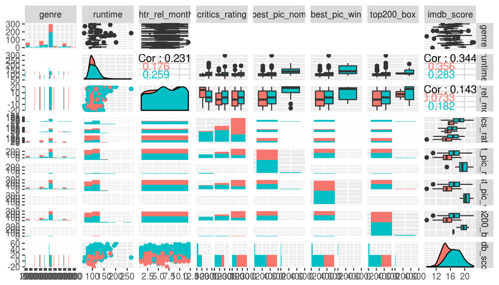

```r
selected_cols <- c("genre","runtime","thtr_rel_month","critics_rating","best_pic_nom","best_pic_win","top200_box","imdb_score")

  c_movies <- na.omit(movies)
  ggpairs(c_movies,
          columns = selected_cols,
          mapping = aes(color = audience_rating),
          lower = list(combo = wrap("facethist", binwidth = 40)))
```

**forward elimination**

Lets perform the forward elimination model selection with selecting high adjusted R-squared at each step.

```r
reduced_cols <- c("genre","runtime","thtr_rel_month","critics_rating","best_pic_nom","best_pic_win","top200_box","imdb_score")

    selected_cols     <- c()
    selected_cols_str <- paste(selected_cols, collapse=", ")
    print(selected_cols_str)
```

```
## [1] ""
```

```r
    for (i in 1:length(reduced_cols)) {
        f <- paste("audience_score","~", selected_cols_str, reduced_cols[i])
        model = lm(formula=f, data = movies)
        print(paste(f," => ", summary(model)$adj.r.squared))
    }
```

```
## [1] "audience_score ~  genre  =>  0.181556287946631"
## [1] "audience_score ~  runtime  =>  0.0312548989483175"
## [1] "audience_score ~  thtr_rel_month  =>  -0.000470529142357456"
## [1] "audience_score ~  critics_rating  =>  0.375578296208879"
## [1] "audience_score ~  best_pic_nom  =>  0.0436669258757576"
## [1] "audience_score ~  best_pic_win  =>  0.0117789507767483"
## [1] "audience_score ~  top200_box  =>  0.00702825728686585"
## [1] "audience_score ~  imdb_score  =>  0.328460350192648"
```

We select `critics_rating` with adjusted R-squared as `0.375578296208879`

```r
    selected_cols     <- c("critics_rating")
    reduced_cols      <- reduced_cols[reduced_cols != selected_cols]
    selected_cols_str <- paste(selected_cols, collapse=" + ")
    print(selected_cols_str)
```

```
## [1] "critics_rating"
```

```r
    for (i in 1:length(reduced_cols)) {
        f <- paste("audience_score","~", selected_cols_str, " + " , reduced_cols[i])
        model = lm(formula=f, data = movies)
        print(paste(f," => ", summary(model)$adj.r.squared))
    }
```

```
## [1] "audience_score ~ critics_rating  +  genre  =>  0.432650982015913"
## [1] "audience_score ~ critics_rating  +  runtime  =>  0.38430769495162"
## [1] "audience_score ~ critics_rating  +  thtr_rel_month  =>  0.374755350539467"
## [1] "audience_score ~ critics_rating  +  best_pic_nom  =>  0.382112844281114"
## [1] "audience_score ~ critics_rating  +  best_pic_win  =>  0.375410015765499"
## [1] "audience_score ~ critics_rating  +  top200_box  =>  0.374943522235776"
## [1] "audience_score ~ critics_rating  +  imdb_score  =>  0.498889588051879"
```

We select `imdb_score` with adjusted R-squared as `0.498889588051879`

```r
    selected_cols     <- c("critics_rating", "imdb_score")
    reduced_cols      <- reduced_cols[reduced_cols != "imdb_score"]
    selected_cols_str <- paste(selected_cols, collapse=" + ")
    print(selected_cols_str)
```

```
## [1] "critics_rating + imdb_score"
```

```r
    for (i in 1:length(reduced_cols)) {
        f <- paste("audience_score","~", selected_cols_str, " + " , reduced_cols[i])
        model = lm(formula=f, data = movies)
        print(paste(f," => ", summary(model)$adj.r.squared))
    }
```

```
## [1] "audience_score ~ critics_rating + imdb_score  +  genre  =>  0.609139098741606"
## [1] "audience_score ~ critics_rating + imdb_score  +  runtime  =>  0.498647668992818"
## [1] "audience_score ~ critics_rating + imdb_score  +  thtr_rel_month  =>  0.499246126758942"
## [1] "audience_score ~ critics_rating + imdb_score  +  best_pic_nom  =>  0.498645058637949"
## [1] "audience_score ~ critics_rating + imdb_score  +  best_pic_win  =>  0.498387610780303"
## [1] "audience_score ~ critics_rating + imdb_score  +  top200_box  =>  0.499380328995121"
```

```r
    selected_cols     <- c("critics_rating", "imdb_score", "thtr_rel_month")
    reduced_cols      <- reduced_cols[reduced_cols != "thtr_rel_month"]
    selected_cols_str <- paste(selected_cols, collapse=" + ")
    print(selected_cols_str)
```

```
## [1] "critics_rating + imdb_score + thtr_rel_month"
```

```r
    for (i in 1:length(reduced_cols)) {
        f <- paste("audience_score","~", selected_cols_str, " + " , reduced_cols[i])
        model = lm(formula=f, data = movies)
        print(paste(f," => ", summary(model)$adj.r.squared))
    }
```

```
## [1] "audience_score ~ critics_rating + imdb_score + thtr_rel_month  +  genre  =>  0.610526828499511"
## [1] "audience_score ~ critics_rating + imdb_score + thtr_rel_month  +  runtime  =>  0.498862938964456"
## [1] "audience_score ~ critics_rating + imdb_score + thtr_rel_month  +  best_pic_nom  =>  0.499253277300928"
## [1] "audience_score ~ critics_rating + imdb_score + thtr_rel_month  +  best_pic_win  =>  0.498707939564811"
## [1] "audience_score ~ critics_rating + imdb_score + thtr_rel_month  +  top200_box  =>  0.499614583432354"
```

We select `genre` with adjusted R-squared as `0.610526828499511`

```r
    selected_cols     <- c("critics_rating", "imdb_score", "thtr_rel_month", "genre")
    reduced_cols      <- reduced_cols[reduced_cols != "genre"]
    selected_cols_str <- paste(selected_cols, collapse=" + ")
    print(selected_cols_str)
```

```
## [1] "critics_rating + imdb_score + thtr_rel_month + genre"
```

```r
    for (i in 1:length(reduced_cols)) {
        f <- paste("audience_score","~", selected_cols_str, " + " , reduced_cols[i])
        model = lm(formula=f, data = movies)
        print(paste(f," => ", summary(model)$adj.r.squared))
    }
```

```
## [1] "audience_score ~ critics_rating + imdb_score + thtr_rel_month + genre  +  runtime  =>  0.610239642067133"
## [1] "audience_score ~ critics_rating + imdb_score + thtr_rel_month + genre  +  best_pic_nom  =>  0.611194599270699"
## [1] "audience_score ~ critics_rating + imdb_score + thtr_rel_month + genre  +  best_pic_win  =>  0.609984096763282"
## [1] "audience_score ~ critics_rating + imdb_score + thtr_rel_month + genre  +  top200_box  =>  0.610022406200753"
```

We select `best_pic_nom` with adjusted R-squared as `0.611194599270699`

```r
    selected_cols     <- c("critics_rating", "imdb_score", "thtr_rel_month", "genre", "best_pic_nom")
    reduced_cols      <- reduced_cols[reduced_cols != "best_pic_nom"]
    selected_cols_str <- paste(selected_cols, collapse=" + ")
    print(selected_cols_str)
```

```
## [1] "critics_rating + imdb_score + thtr_rel_month + genre + best_pic_nom"
```

```r
    for (i in 1:length(reduced_cols)) {
        f <- paste("audience_score","~", selected_cols_str, " + " , reduced_cols[i])
        model = lm(formula=f, data = movies)
        print(paste(f," => ", summary(model)$adj.r.squared))
    }
```

```
## [1] "audience_score ~ critics_rating + imdb_score + thtr_rel_month + genre + best_pic_nom  +  runtime  =>  0.611171107708812"
## [1] "audience_score ~ critics_rating + imdb_score + thtr_rel_month + genre + best_pic_nom  +  best_pic_win  =>  0.611292953208765"
## [1] "audience_score ~ critics_rating + imdb_score + thtr_rel_month + genre + best_pic_nom  +  top200_box  =>  0.610698366559542"
```

We select `best_pic_win` with adjusted R-squared as `0.611292953208765`

```r
    selected_cols     <- c("critics_rating", "imdb_score", "thtr_rel_month", "genre", "best_pic_nom", "best_pic_win")
    reduced_cols      <- reduced_cols[reduced_cols != "best_pic_win"]
    selected_cols_str <- paste(selected_cols, collapse=" + ")
    print(selected_cols_str)
```

```
## [1] "critics_rating + imdb_score + thtr_rel_month + genre + best_pic_nom + best_pic_win"
```

```r
    for (i in 1:length(reduced_cols)) {
        f <- paste("audience_score","~", selected_cols_str, " + " , reduced_cols[i])
        model = lm(formula=f, data = movies)
        print(paste(f," => ", summary(model)$adj.r.squared))
    }
```

```
## [1] "audience_score ~ critics_rating + imdb_score + thtr_rel_month + genre + best_pic_nom + best_pic_win  +  runtime  =>  0.611158749075273"
## [1] "audience_score ~ critics_rating + imdb_score + thtr_rel_month + genre + best_pic_nom + best_pic_win  +  top200_box  =>  0.610777760906041"
```

We can see there is no increment in the adjusted R-squared value and hence we have selected the best parsimonious predictors for the model after 7 steps of forward elimination. The predictors are

1. critics_rating
2. imdb_score
3. thtr_rel_month
4. genre
5. best_pic_nom
6. best_pic_win

```r
  fw_model <- lm(audience_score ~ critics_rating + imdb_score + thtr_rel_month + genre + best_pic_nom + best_pic_win, data = movies)
  summary(fw_model)
```

```
##
## Call:
## lm(formula = audience_score ~ critics_rating + imdb_score + thtr_rel_month +
##     genre + best_pic_nom + best_pic_win, data = movies)
##
## Residuals:
##     Min      1Q  Median      3Q     Max
## -41.006  -8.057   0.247   8.483  44.360
##
## Coefficients:
##                                Estimate Std. Error t value Pr(>|t|)
## (Intercept)                    -14.8207     5.6932  -2.603 0.009451 **
## critics_ratingFresh              1.1911     1.5420   0.772 0.440114
## critics_ratingRotten           -11.0971     1.6285  -6.814 2.21e-11 ***
## imdb_score                       4.7626     0.2838  16.782  < 2e-16 ***
## thtr_rel_month                  -0.2898     0.1427  -2.031 0.042694 *
## genreAnimation                   7.9413     4.5004   1.765 0.078119 .
## genreArt House & International  13.0397     3.7509   3.476 0.000543 ***
## genreComedy                      3.2802     2.0884   1.571 0.116756
## genreDocumentary                26.8919     2.5451  10.566  < 2e-16 ***
## genreDrama                       7.5041     1.7715   4.236 2.61e-05 ***
## genreHorror                     -2.9652     3.0774  -0.964 0.335640
## genreMusical & Performing Arts  22.1549     4.0125   5.521 4.91e-08 ***
## genreMystery & Suspense         -2.2905     2.2902  -1.000 0.317627
## genreOther                       6.7248     3.5756   1.881 0.060464 .
## genreScience Fiction & Fantasy  -3.1510     4.5074  -0.699 0.484760
## best_pic_nomyes                  5.7818     3.2638   1.771 0.076960 .
## best_pic_winyes                 -5.9208     5.4958  -1.077 0.281736
## ---
## Signif. codes:  0 '***' 0.001 '**' 0.01 '*' 0.05 '.' 0.1 ' ' 1
##
## Residual standard error: 12.61 on 634 degrees of freedom
## Multiple R-squared:  0.6209, Adjusted R-squared:  0.6113
## F-statistic: 64.89 on 16 and 634 DF,  p-value: < 2.2e-16
```

**backward elimination**

Lets perform the backward elimination model selection with selecting high adjusted R-squared at each step. To start with lets make the model with all the variable.

```r
    all_cols     <- c("genre","runtime","thtr_rel_month","critics_rating","best_pic_nom","best_pic_win","top200_box","imdb_score")

    f <- paste("audience_score","~", paste(all_cols, collapse=" + "))
    model = lm(formula=f, data = movies)
    print(summary(model)$adj.r.squared)
```

```
## [1] 0.6106133
```

```r
    all_cols     <- c("genre","runtime","thtr_rel_month","critics_rating","best_pic_nom","best_pic_win","top200_box","imdb_score")

    reduced_cols <- all_cols
    reduced_cols_str <- paste("audience_score","~",paste(reduced_cols, collapse=" + "))
    print(reduced_cols_str)
```

```
## [1] "audience_score ~ genre + runtime + thtr_rel_month + critics_rating + best_pic_nom + best_pic_win + top200_box + imdb_score"
```

```r
    for (i in 1:length(all_cols)) {
        reduced_cols      <- all_cols
        reduced_cols      <- reduced_cols[reduced_cols != all_cols[i]]
        reduced_cols_str  <- paste(reduced_cols, collapse=" + ")

        f <- paste("audience_score","~", reduced_cols_str)
        model = lm(formula=f, data = movies)
        print(paste(all_cols[i]," => ", summary(model)$adj.r.squared))
    }
```

```
## [1] "genre  =>  0.499390651120926"
## [1] "runtime  =>  0.610777760906041"
## [1] "thtr_rel_month  =>  0.609247712586131"
## [1] "critics_rating  =>  0.547227021042473"
## [1] "best_pic_nom  =>  0.609118441306124"
## [1] "best_pic_win  =>  0.610638216061963"
## [1] "top200_box  =>  0.611158749075273"
## [1] "imdb_score  =>  0.445561248389702"
```

We eliminate `top200_box` and obtain high adjusted R-squared `0.611158749075273`

```r
    all_cols     <- c("genre","runtime","thtr_rel_month","critics_rating","best_pic_nom","best_pic_win","imdb_score")

    reduced_cols <- all_cols
    reduced_cols_str <- paste("audience_score","~",paste(reduced_cols, collapse=" + "))
    print(reduced_cols_str)
```

```
## [1] "audience_score ~ genre + runtime + thtr_rel_month + critics_rating + best_pic_nom + best_pic_win + imdb_score"
```

```r
    for (i in 1:length(all_cols)) {
        reduced_cols      <- all_cols
        reduced_cols      <- reduced_cols[reduced_cols != all_cols[i]]
        reduced_cols_str  <- paste(reduced_cols, collapse=" + ")

        f <- paste("audience_score","~", reduced_cols_str)
        model = lm(formula=f, data = movies)
        print(paste(all_cols[i]," => ", summary(model)$adj.r.squared))
    }
```

```
## [1] "genre  =>  0.49912260723431"
## [1] "runtime  =>  0.611292953208765"
## [1] "thtr_rel_month  =>  0.609755653600492"
## [1] "critics_rating  =>  0.547941096632871"
## [1] "best_pic_nom  =>  0.609655640761888"
## [1] "best_pic_win  =>  0.611171107708812"
## [1] "imdb_score  =>  0.44550250141041"
```

We eliminate `runtime` and obtain high adjusted R-squared `0.611292953208765`

```r
    all_cols     <- c("genre","thtr_rel_month","critics_rating","best_pic_nom","best_pic_win","imdb_score")

    reduced_cols <- all_cols
    reduced_cols_str <- paste("audience_score","~",paste(reduced_cols, collapse=" + "))
    print(reduced_cols_str)
```

```
## [1] "audience_score ~ genre + thtr_rel_month + critics_rating + best_pic_nom + best_pic_win + imdb_score"
```

```r
    for (i in 1:length(all_cols)) {
        reduced_cols      <- all_cols
        reduced_cols      <- reduced_cols[reduced_cols != all_cols[i]]
        reduced_cols_str  <- paste(reduced_cols, collapse=" + ")

        f <- paste("audience_score","~", reduced_cols_str)
        model = lm(formula=f, data = movies)
        print(paste(all_cols[i]," => ", summary(model)$adj.r.squared))
    }
```

```
## [1] "genre  =>  0.499414944081151"
## [1] "thtr_rel_month  =>  0.609380587587638"
## [1] "critics_rating  =>  0.547667743940504"
## [1] "best_pic_nom  =>  0.609984096763282"
## [1] "best_pic_win  =>  0.611194599270698"
## [1] "imdb_score  =>  0.439506852607386"
```

We can see that we cannot improve the model anymore with eliminating any variable. we have achieved the parsimonious model with the following predictors after 3 steps of backward elimination 1. genre 2. thtr_rel_month 3. critics_rating 4. best_pic_nom 5. best_pic_win 6. imdb_score

```r
  bw_model <- lm(audience_score ~ genre + thtr_rel_month + critics_rating + best_pic_nom + best_pic_win + imdb_score, data = movies)
  summary(bw_model)
```

```
##
## Call:
## lm(formula = audience_score ~ genre + thtr_rel_month + critics_rating +
##     best_pic_nom + best_pic_win + imdb_score, data = movies)
##
## Residuals:
##     Min      1Q  Median      3Q     Max
## -41.006  -8.057   0.247   8.483  44.360
##
## Coefficients:
##                                Estimate Std. Error t value Pr(>|t|)
## (Intercept)                    -14.8207     5.6932  -2.603 0.009451 **
## genreAnimation                   7.9413     4.5004   1.765 0.078119 .
## genreArt House & International  13.0397     3.7509   3.476 0.000543 ***
## genreComedy                      3.2802     2.0884   1.571 0.116756
## genreDocumentary                26.8919     2.5451  10.566  < 2e-16 ***
## genreDrama                       7.5041     1.7715   4.236 2.61e-05 ***
## genreHorror                     -2.9652     3.0774  -0.964 0.335640
## genreMusical & Performing Arts  22.1549     4.0125   5.521 4.91e-08 ***
## genreMystery & Suspense         -2.2905     2.2902  -1.000 0.317627
## genreOther                       6.7248     3.5756   1.881 0.060464 .
## genreScience Fiction & Fantasy  -3.1510     4.5074  -0.699 0.484760
## thtr_rel_month                  -0.2898     0.1427  -2.031 0.042694 *
## critics_ratingFresh              1.1911     1.5420   0.772 0.440114
## critics_ratingRotten           -11.0971     1.6285  -6.814 2.21e-11 ***
## best_pic_nomyes                  5.7818     3.2638   1.771 0.076960 .
## best_pic_winyes                 -5.9208     5.4958  -1.077 0.281736
## imdb_score                       4.7626     0.2838  16.782  < 2e-16 ***
## ---
## Signif. codes:  0 '***' 0.001 '**' 0.01 '*' 0.05 '.' 0.1 ' ' 1
##
## Residual standard error: 12.61 on 634 degrees of freedom
## Multiple R-squared:  0.6209, Adjusted R-squared:  0.6113
## F-statistic: 64.89 on 16 and 634 DF,  p-value: < 2.2e-16
```

**Checking Model Assumptions:**

The follwoing plots of the forward eliminated model residuals shows that they are nearly normal.

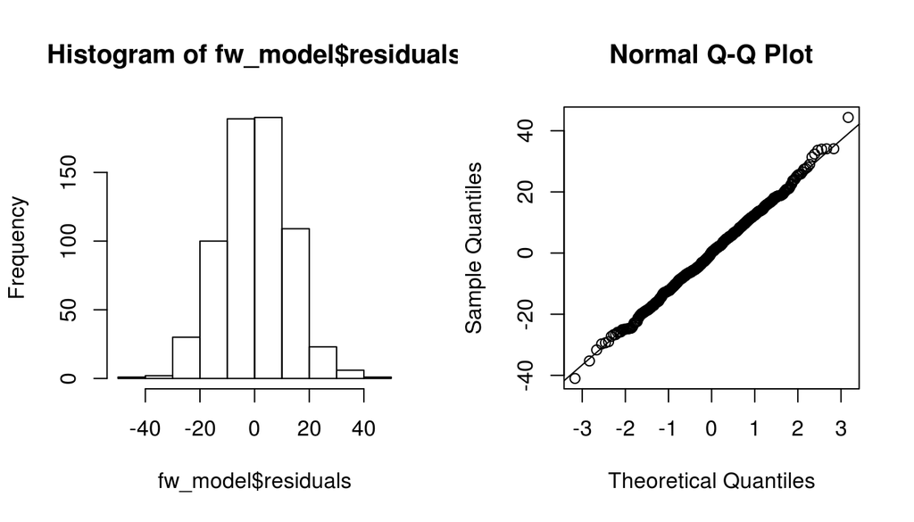

```r
  par(mfrow=c(1,2))
  hist(fw_model$residuals)
  qqnorm(fw_model$residuals)
  qqline(fw_model$residuals)
```

The follwoing plots of the backward eliminated model residuals shows that they are nearly normal.

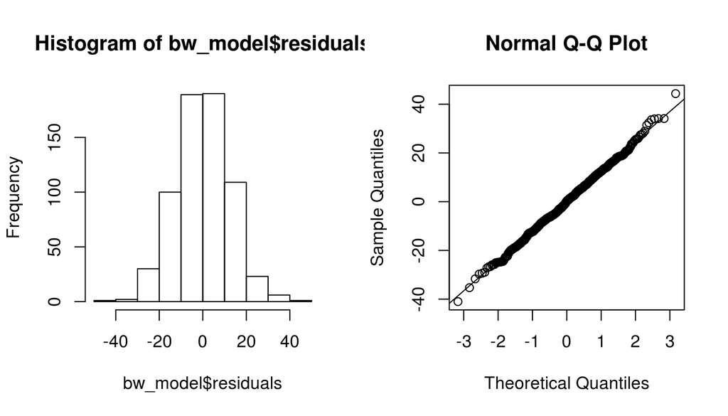

```r
  par(mfrow=c(1,2))
  hist(bw_model$residuals)
  qqnorm(bw_model$residuals)
  qqline(bw_model$residuals)
```

Both the models doest show any heteroscedasticity in the plots with `model$fitted.values vs model$residuals`

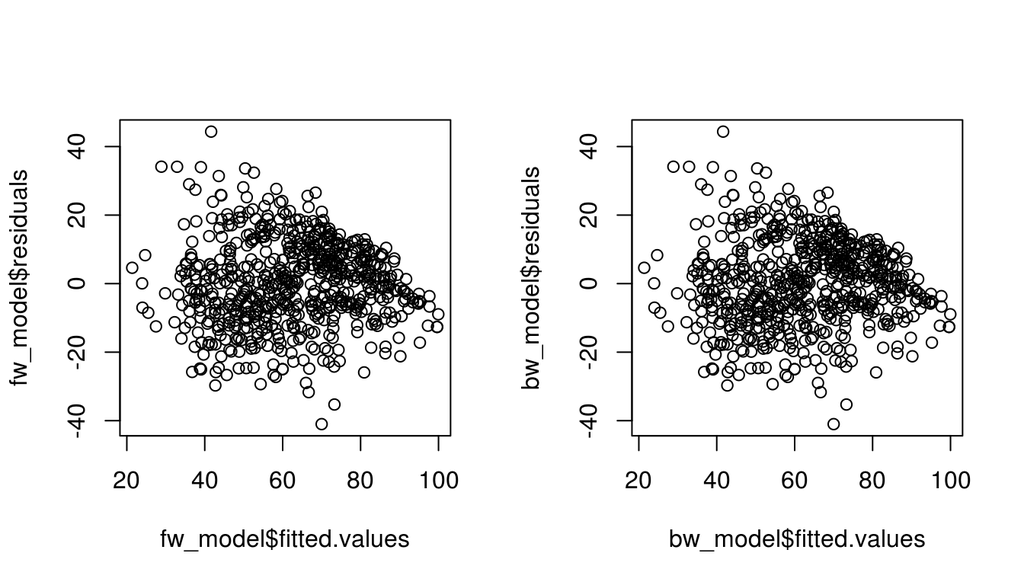

```r
  par(mfrow=c(1,2))
  plot(fw_model$fitted.values, fw_model$residuals)
  plot(bw_model$fitted.values, bw_model$residuals)
```

## Part 5: Prediction

Both the model has high adjusted R-square value, but we will choose backward eliminated model for making predictions on the audience score base on selected predictors

```r
  predictors <- c("genre","thtr_rel_month","critics_rating","best_pic_nom","best_pic_win","imdb_score","audience_score")
predict.movie.audience_score <- function(title) {
  movie <- movies[movies$title %in% c(title),]
  predict(bw_model, newdata=movie, interval="prediction")
}
```

Lets predict the audience score for the following movies

```r
  print(xtable(movies[movies$title %in% c("Titanic"),][predictors]), type = "html")
```

|  | genre | thtr_rel_month | critics_rating | best_pic_nom | best_pic_win | imdb_score | audience_score |
| --- | --- | --- | --- | --- | --- | --- | --- |
| 1 | Drama | 12.00 | Certified Fresh | yes | yes | 21.24 | 69.00 |

```r
  predict.movie.audience_score("Titanic")
```

```
##       fit      lwr      upr
## 1 90.2077 63.70446 116.7109
```

```r
  print(xtable(movies[movies$title %in% c("Pina"),][predictors]), type = "html")
```

|  | genre | thtr_rel_month | critics_rating | best_pic_nom | best_pic_win | imdb_score | audience_score |
| --- | --- | --- | --- | --- | --- | --- | --- |
| 1 | Musical & Performing Arts | 12.00 | Certified Fresh | no | no | 17.02 | 81.00 |

```r
  predict.movie.audience_score("Pina")
```

```
##      fit      lwr      upr
## 1 84.932 59.07315 110.7909
```

```r
  print(xtable(movies[movies$title %in% c("Taps"),][predictors]), type = "html")
```

|  | genre | thtr_rel_month | critics_rating | best_pic_nom | best_pic_win | imdb_score | audience_score |
| --- | --- | --- | --- | --- | --- | --- | --- |
| 1 | Drama | 12.00 | Fresh | no | no | 16.13 | 67.00 |

```r
  predict.movie.audience_score("Taps")
```

```
##        fit     lwr      upr
## 1 67.23332 42.3462 92.12045
```

```r
  print(xtable(movies[movies$title %in% c("A Good Woman"),][predictors]), type = "html")
```

|  | genre | thtr_rel_month | critics_rating | best_pic_nom | best_pic_win | imdb_score | audience_score |
| --- | --- | --- | --- | --- | --- | --- | --- |
| 1 | Drama | 2.00 | Rotten | no | no | 15.65 | 49.00 |

```r
  predict.movie.audience_score("A Good Woman")
```

```
##        fit      lwr      upr
## 1 55.53302 30.66597 80.40007
```

```r
  print(xtable(movies[movies$title %in% c("Serpico"),][predictors]), type = "html")
```

|  | genre | thtr_rel_month | critics_rating | best_pic_nom | best_pic_win | imdb_score | audience_score |
| --- | --- | --- | --- | --- | --- | --- | --- |
| 1 | Drama | 12.00 | Fresh | no | no | 19.03 | 88.00 |

```r
  predict.movie.audience_score("Serpico")
```

```
##        fit      lwr      upr
## 1 81.03588 56.11271 105.9591
```

We can see the predicted range for the movie’s audience score interval always contains the real audience score.